# Lab 1: Introduction to R and RStudio

Carlo Gaetan

# Introduction

In this class, we will be using the [R language](https://www.r-project.org) heavily in class notes, examples and lab exercises. R is free and you can install it like any other program on your computer.

1. Go to the [CRAN](https://cloud.r-project.org/) website and download it for your Mac or PC. (We assume no one is using Linux; if you are that advanced, then you already know what to do!)
2. Install the free version of the [RStudio](https://www.rstudio.com/products/rstudio/download/) Desktop Software.

RStudio makes it very easy to learn and use R, providing a number of useful features that many find indispensable.

## About the R language, briefly

If you are used to traditional computing languages, you will find R different in many ways. The basic ideas behind R date back four decades and have a strong flavor of exploration: one can grapple with data, understand its structure, visualize it, summarize it etc. Therefore, a common way people use R is by typing a command and immediately see the results. (Of course, scripts can also be written and fed to R for batch execution.)

- *Program for data analysis* For many people R is a program of choice for statistical analysis, visualization and predictive analytics.
- *Programming language* Data analysis with functions and scripting. Interactive programming language.
- *Environment for statistical analysis* Access to standard models and cutting edge methods.
- *Open Source project* Open source code. Free. Over 15 years of peer review. Integration with other tools/systems.
- *Community* 20 people in R Core. Approximately 2 mln users worldwide: forums, mailing lists, blogs.

The core of R itself is reasonably small, but over time, it has also become a vehicle for researchers to disseminate new tools and methodologies via packages.

The [CRAN](https://cloud.r-project.org) website is something you will consult frequently for both the software, documentation and packages others have developed.

## RStudio

We can only cover some important aspects of RStudio here. There are a number of resources online, including Youtube videos that you can consult outside of class.

When you start RStudio, you will get a view similar to what is shown below with perhaps slight differences.

[figure not shown]

One can type commands directly into the console window and see results. For example, go ahead and type `1+1` to use R as a calculator and see the result. However, one often wants to write a sequence of commands, execute them and possibly save the commands to run them again another time. That’s what the editor window is for. You can type a series of commands into the editor window and RStudio will offer to save them when you quit, and bring them back when you restart RStudio.

If you type

```r
x = 1 + 1
y = 2 * x
z <- (x + y)
```

into the editor window, you can press the `Run` arrow shown and execute each line in the R console, one by one. The figure below shows this and as new variables are created, the workspace panel displays them.

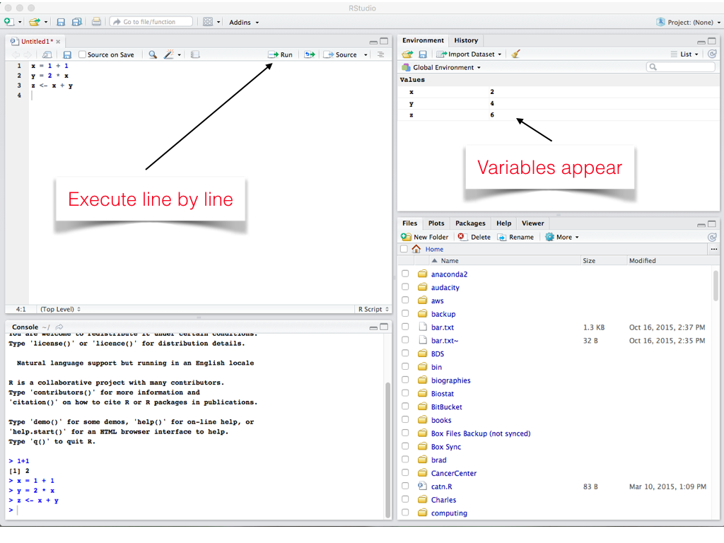

### Should I use `=` or `<-` for assignment?

In R, both `=` and `<-` can be used for assigning a value to variables. No preference.

### Help

A lot of help is available in RStudio in the help tab that you should feel free to investigate. We merely point out a few.

[figure not shown]

When anyone installs R, there is a set of recommended packages that is always installed. So your *installed packages* will reflect that. As we proceed, you will have to install many packages and that list will, of course, grow.

# Interacting with R

## R console and R syntax

R syntax is

- Case-sensitive.
- $\#$ is a comment character
- Spaces and line breaks can be used generously.

```r
# This is a comment describing that below we are computing
# the square root of 4
 sqrt(4
 )
```

## R as an advanced calculator

Type-in a mathematical formula and press Enter

Examples:

- simple computations

```r
2 + 2
```

```
## [1] 4
```

- correct operator precedence

```r
3 + 2 * 3
```

```
## [1] 9
```

- mathematical functions and constants

```r
sin(pi/2)^2
```

```
## [1] 1
```

- complex formulas

```r
(3 * 2^2 - 4 * 3^2 )*cos(3/4*pi)
```

```
## [1] 16.97056
```

## Assignment

Computing would be useless if you cannot store a result for later use.

- Use ’<- (left arrow) to assign a result to a named object
- Typing name of the object will print its contents.
- Object name can consist of alphanumeric characters, ‘_’, and ‘.’. Cannot start with a number though.

```r
x <- 3 + 2 * 3 # storing result as 'x'
x
```

```
## [1] 9
```

```r
some_new.name <- x + 11 # reusing 'x'
some_new.name
```

```
## [1] 20
```

## Using functions

Functions are the pillars of R.

- Computations.
- Data manipulation and transformation.
- Visualization.
- Estimation of statistical models.
- etc. . .

A function is also an object. It has a name and arguments (inputs):

```r
log
```

```
## function (x, base = exp(1))  .Primitive("log")
```

## Calling functions

Function arguments can be specified in different ways:

```r
log(1) # using default value of 'base' argument
```

```
## [1] 0
```

```r
log(2, base=2) # specifying value of 'base' by name
```

```
## [1] 1
```

```r
log(2, 10) # specifying value of 'base' by order
```

```
## [1] 0.30103
```

Values returned by one function can become an argument to different function:

```r
log(exp(1),exp(1))
```

```
## [1] 1
```

## Help system

In the help system:

- Manuals.
- Package help pages.
- Help pages of individual functions.

## Accessing help

- Using dedicated panel in RStudio
- Using functions `help` and `help.search`

## R Session Management

All variables created in R are stored in the workplace. To see which variables are currently present, type:

```r
ls()
```

```
## [1] "some_new.name" "x"             "y"             "z"
```

to remove a variable, type:

```r
rm(x)
```

To remove the entire workspace, type:

```r
rm(list=ls())
```

To save the workspace to a file, write:

```r
save.image()
```

Then, a file with suffix `.RData` will be created in your working directory.

You can also do this by the traditional File/Save Workspace on the pull-down menu.

Note that the .Rdata file will be started by default when R is restarted.

# Vectors

- Vector is a basic type of R object.
- Ordered collection of elements of the same type.
- Elements: numbers, strings, logical values (TRUE/FALSE).

## Creation

```r
weight <- c(60,72,57,90,95) # Numerical vector
weight
```

```
## [1] 60 72 57 90 95
```

Here, `c` stands for concatenate (joining items from end to end)

A named numeric vector

```r
wnamed<-c(a=60,sec=72,Bill=4)
wnamed
```

```
##    a  sec Bill
##   60   72    4
```

```r
friends<-c('Lucy','Andrew',
        'Tim',"Charlie","Bob") #  A vector of text strings
```

```r
girls<-c(TRUE,FALSE,FALSE,
        FALSE, FALSE) #  A vector of logical values
```

Special element for missing value: NA. More on that later.

## Obiect Class

One of the most useful attributes for describing an entity in R is the object’s class. Every object you create is identified, either implicitly or explicitly, with at least one class. In the parlance of object-oriented programming - where entities are stored as objects and have methods that act upon them—this *identification* is quite important and is formally referred to as *inheritance* (a term that references the adoption of features of a specific, recognized type of object).

```r
class(weight)
```

```
## [1] "numeric"
```

```r
class(friends)
```

```
## [1] "character"
```

```r
class(girls)
```

```
## [1] "logical"
```

## Computing with vectors

Computations on vectors are performed element-wise (element by element).

Arithmetic operators: +, -, *, /, ^ , (powers)

```r
height <-c(1.75, 1.80, 1.65, 1.90, 1.74)
bmi <- weight/height^2
bmi
```

```
## [1] 19.59184 22.22222 20.93664 24.93075 31.37799
```

Logical operators: ==, <=, >=, <, >, ! (not), != (not equal).

```r
friends == 'Tim'
```

```
## [1] FALSE FALSE  TRUE FALSE FALSE
```

Common functions for numeric vectors: `length`, `sum`, `mean`.

```r
length(weight)
```

```
## [1] 5
```

```r
sum(weight)
```

```
## [1] 374
```

```r
# do you remember the mean ?
xbar <- sum(weight)/length(weight)
xbar
```

```
## [1] 74.8
```

Common functions for logical vectors: `any`, `all`, `which`, `\%in\%` operator.

```r
any(weight < 70)
```

```
## [1] TRUE
```

```r
all(weight < 70)
```

```
## [1] FALSE
```

```r
which(weight < 70)
```

```
## [1] 1 3
```

```r
weight %in% 70
```

```
## [1] FALSE FALSE FALSE FALSE FALSE
```

`names` returns character vector of element names.

```r
names(wnamed)
```

```
## [1] "a"    "sec"  "Bill"
```

Convert between vector types with: `as.numeric`, `as.character`, `as.logical`

```r
as.character(weight)
```

```
## [1] "60" "72" "57" "90" "95"
```

Creating regular vectors with `seq`, `:` operator, `rep`.

```r
seq(2,5,length=4)
```

```
## [1] 2 3 4 5
```

```r
2:5
```

```
## [1] 2 3 4 5
```

```r
rep(2,5)
```

```
## [1] 2 2 2 2 2
```

## Subscripting

Referring to individual elements or subsets of elements of a larger object.

Syntax for subscripting some vector v:

`v[ i ]`

where `i` can be a vector (also of length 1) which is one of:

- numerical: selecting elements on positions given by `i`. Negative `i` means “drop ith element”.

```r
weight[3]
```

```
## [1] 57
```

```r
weight[-3]
```

```
## [1] 60 72 90 95
```

- character: Selecting elements with names given by `i`

```r
wnamed['a']
```

```
##  a
## 60
```

- logical: Selecting elements, for which `i == TRUE`.

```r
height[weight == 72]
```

```
## [1] 1.8
```

Subsetting is also possible

```r
weight
```

```
## [1] 60 72 57 90 95
```

```r
weight[c(2,3)]
```

```
## [1] 72 57
```

```r
wnamed[c('a','Bill')]
```

```
##    a Bill
##   60    4
```

```r
height[weight != 72]
```

```
## [1] 1.75 1.65 1.90 1.74
```

## Missing values

There is a single symbol representing missing value: `NA` (not available).

Most of the basic computations involving NAs will result in an NA.

```r
v <- c(1, 2, NA, 3)
mean(v)
```

```
## [1] NA
```

- Functions to deal with missing values: `is.na`, `na.omit`.

```r
is.na(v)
```

```
## [1] FALSE FALSE  TRUE FALSE
```

# Lists

Lists in R are very general objects that can contain other objects of arbitrary types. List members can be named, or referenced using numeric indices (using the [[ operator).

```r
newlist <- list(first = "hello", second = 42, Bob = TRUE)
is.list(newlist)
```

```
## [1] TRUE
```

```r
newlist
```

```
## $first
## [1] "hello"
##
## $second
## [1] 42
##
## $Bob
## [1] TRUE
```

```r
newlist[[2]]
```

```
## [1] 42
```

```r
newlist$Bob
```

```
## [1] TRUE
```

# Matrices and Arrays

- A matrix is just a two-dimensional array of numbers.
- A matrix can be represented as a vector with dimensions.

```r
matrix(1:12,nrow=3)
```

```
##      [,1] [,2] [,3] [,4]
## [1,]    1    4    7   10
## [2,]    2    5    8   11
## [3,]    3    6    9   12
```

Important: Note that the storage of the numbers 1-12 proceeds down the columns. - To change this so that storage proceeds across the rows, write:

```r
matrix(1:12,nrow=3,byrow=TRUE)
```

```
##      [,1] [,2] [,3] [,4]
## [1,]    1    2    3    4
## [2,]    5    6    7    8
## [3,]    9   10   11   12
```

Here, if `byrow=FALSE` (the default) or `byrow` is omitted, storage is columnwise again. - Other useful matrix functions include `rownames`, `colnames`, and `t` (for transpose), which turns rows into columns, and columns into rows.

```r
z <- matrix(1:12,nrow=3,byrow=TRUE)
rownames(z) <- LETTERS[1:3]
```

```r
z
```

```
##   [,1] [,2] [,3] [,4]
## A    1    2    3    4
## B    5    6    7    8
## C    9   10   11   12
```

```r
t(z)
```

```
##      A B  C
## [1,] 1 5  9
## [2,] 2 6 10
## [3,] 3 7 11
## [4,] 4 8 12
```

- subsets of a matrix

```r
z[1,2]   # element in 1st row, 2nd column
```

```
## A
## 2
```

```r
z[3,]    # 3rd row
```

```
## [1]  9 10 11 12
```

```r
z[,4]    # 4th column
```

```
##  A  B  C
##  4  8 12
```

```r
z[1:2,3:4] # elements in the first two rows and in the 3th and fourth columns
```

```
##   [,1] [,2]
## A    3    4
## B    7    8
```

```r
diag(z)  # main diagonal
```

```
## [1]  1  6 11
```

# Creating functions

R function is also an object, which is created using a function function.

```r
f <- function(x, y)
{
  pr <- x * y
  mean(pr)
}
f(height,weight)
```

```
## [1] 132.99
```

- Function `f` expects two arguments, which are called `x` and `y` within function definition.
- Curly braces `\{` `\`} are used to block several R expressions together.
- Last operation within `\{` `\`} produces the value returned by `f`.

# Plotting X-Y data

## Simple plot

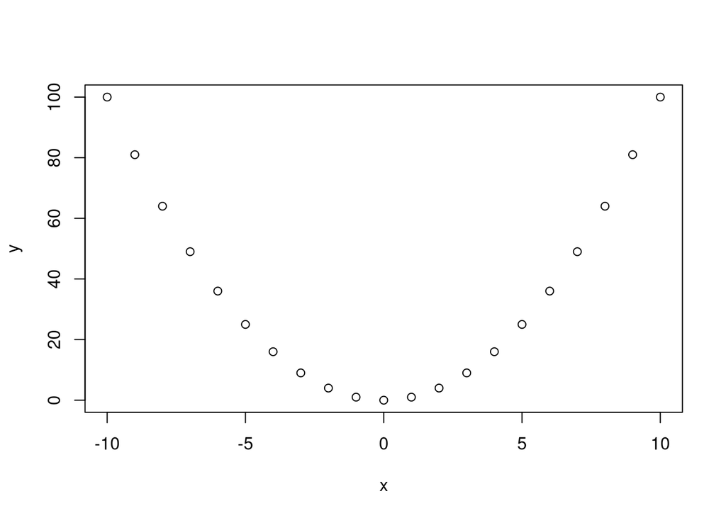

```r
n<-10
x<-(-n):n
y<-x^2
plot(x,y)
```

Labels, title, line plot, colours

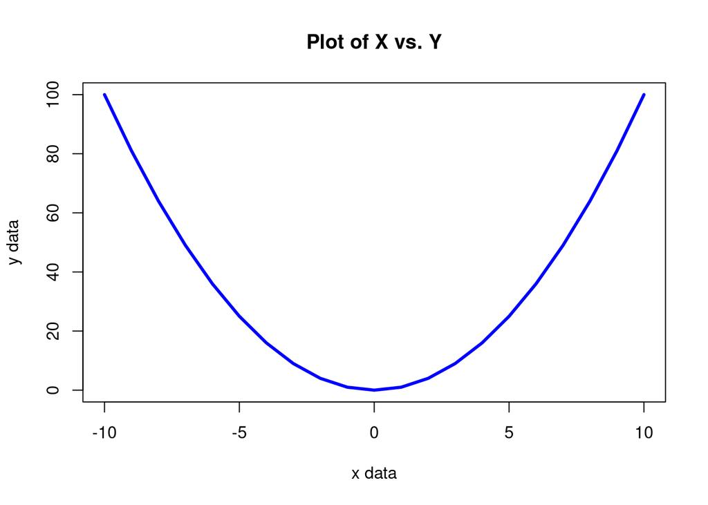

```r
plot(x,y,xlab="x data",ylab="y data",type="l",
   col="blue",lwd=3,main="Plot of X vs. Y")
```

Plotting two graphs in same plot (and add a legend)

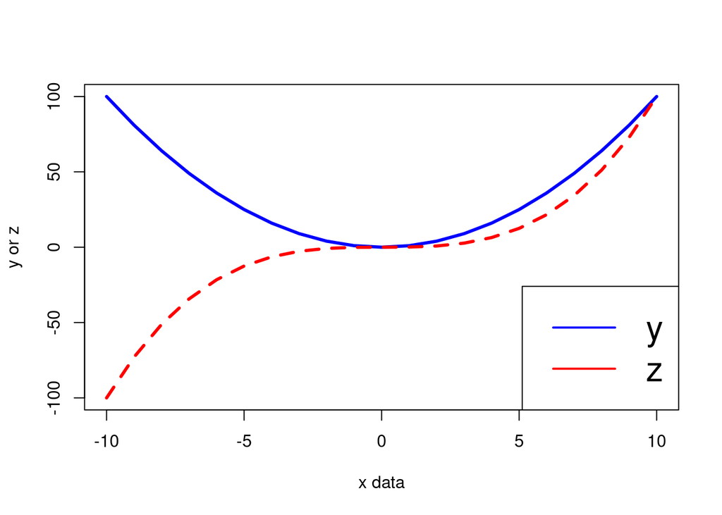

```r
z <- x^3/10
xrange <- range(x)
yrange <-range(y,z)
plot(x,y,xlab="x data",ylab="y or z",type="l",
 col="blue",lwd=3,xlim=xrange,ylim=yrange)
par(new=TRUE)
plot(x,z,xlab="",ylab="",type="l",axes=FALSE,
col="red",lwd=3,xlim=xrange,ylim=yrange,lty="dashed")
legend("bottomright",legend=c("y","z"),
col=c("blue","red"),lwd=2,cex=2)
```

Multiple plots next to each other (and draw a line)

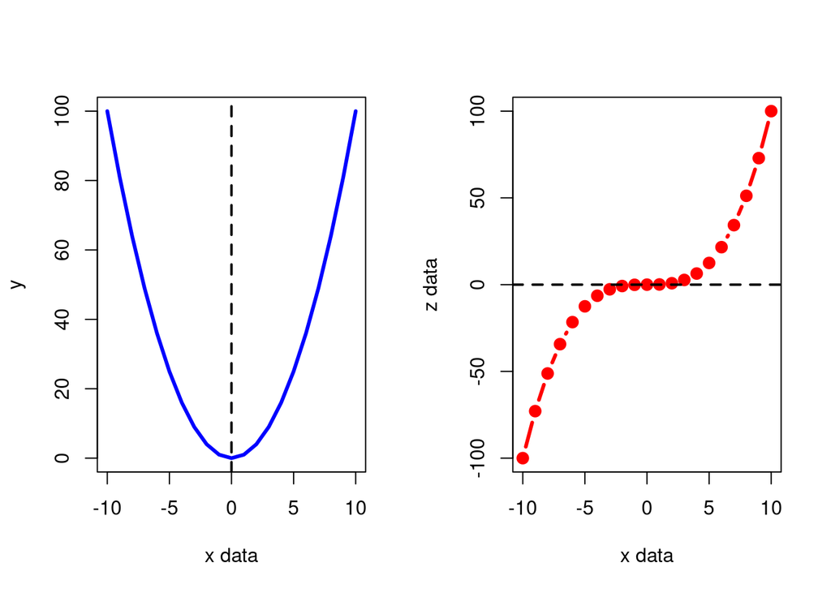

```r
par(mfcol=c(1,2))
plot(x,y,xlab="x data",ylab="y",type="l",
    col="blue",lwd=3)
abline(v=0,lwd=2,lty="dashed") # draw a vertical
                                   # line at 0
plot(x,z,xlab="x data",ylab="z data",type="b",
     col="red",lwd=3,pch=19)
abline(h=0,lwd=2,lty="dashed") # draw a horizontal line at 0
```

## Plotting functions

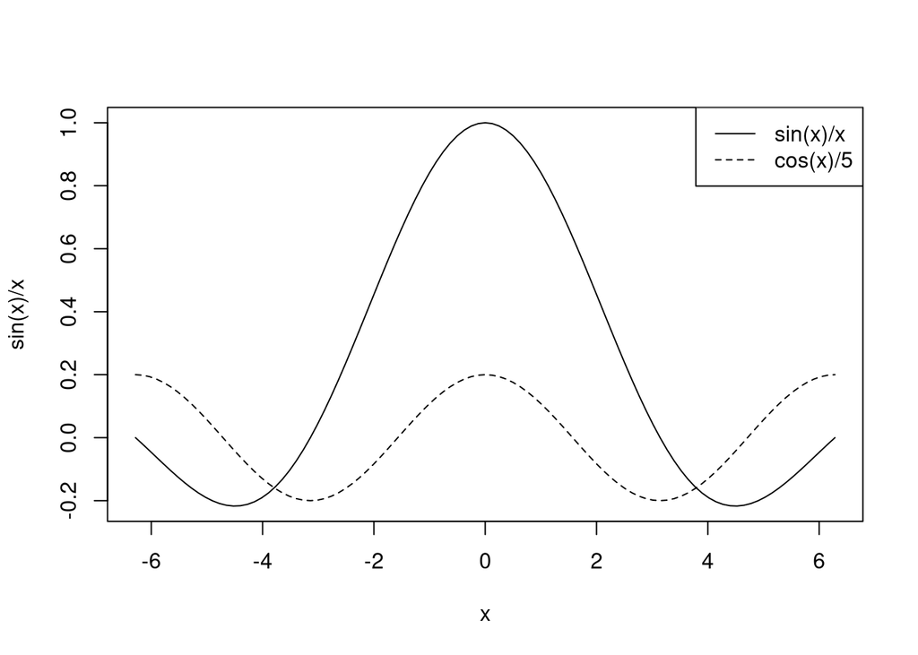

```r
curve(sin(x)/x, from=-2*pi,to=2*pi)
curve(cos(x)/5, from=-2*pi,to=2*pi,add=TRUE,lty=2)
legend("topright",legend=c("sin(x)/x","cos(x)/5"),
   lty=1:2)
```

## 3D plot

Plot of
$$z=
\sqrt{6400^2-(x^2+y^2)}$$

```r
x <- seq(-6400, 6400, length= 60)
y <- x
f <- function(x, y) {
     sqrt(6400^2-(x^2+y^2))
}
z <- outer(x, y, f)
z[is.na(z)] <- 1
```

using `persp` function

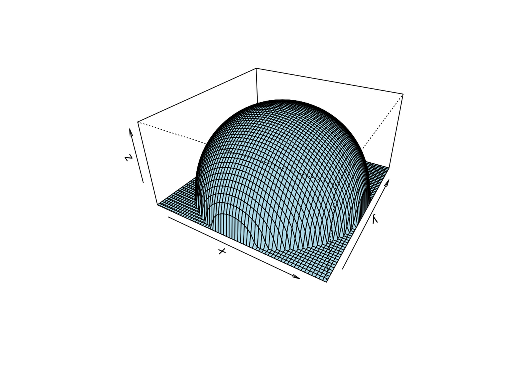

```r
persp(x, y, z, theta = 30, phi = 30,
     expand = 0.5, col = "lightblue")
```

using `image` function

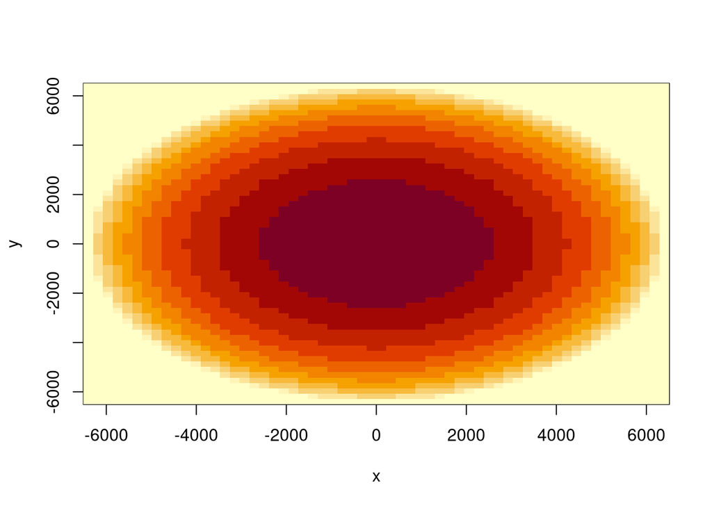

```r
image(x, y, z)
```

using `contour` function

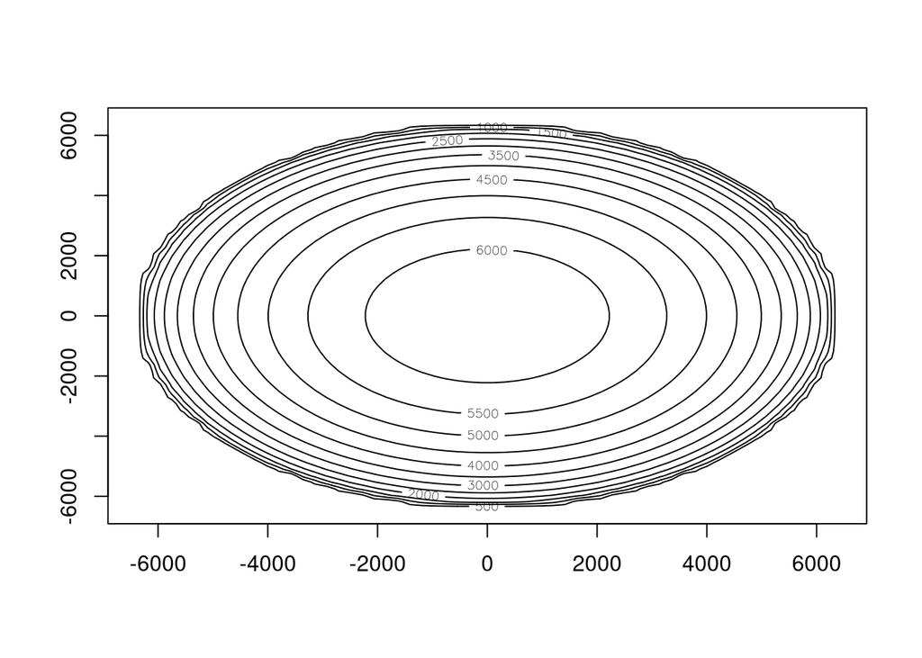

```r
contour(x, y, z)
```

combining them

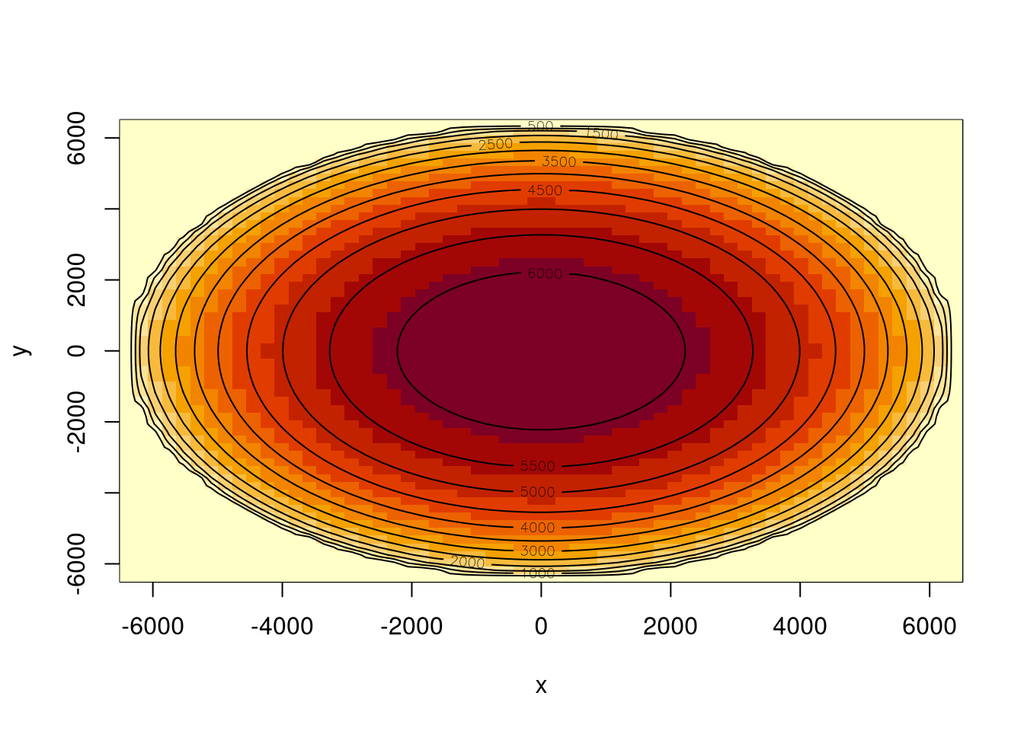

```r
image(x, y, z)
contour(x, y, z,add=TRUE)
```

using `filled.contour`

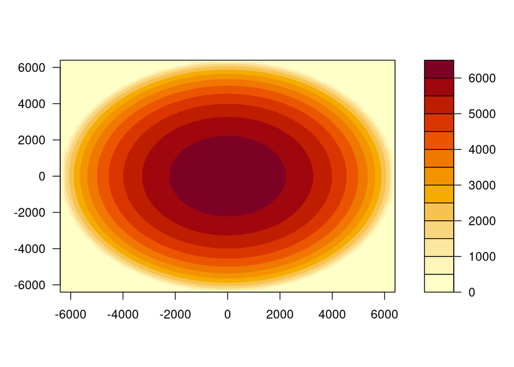

```r
filled.contour(x, y, z)
```

There are other, more beautiful possibilities. Install the `plot3D` package (see the next labs for instructions on how to install a package).

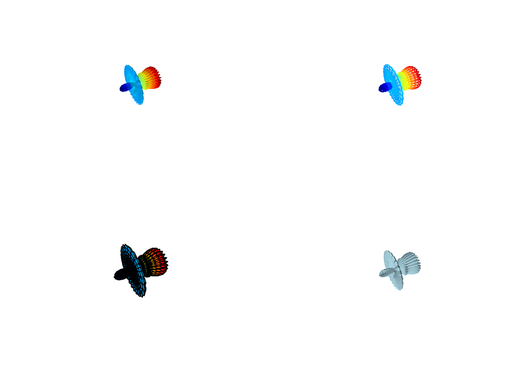

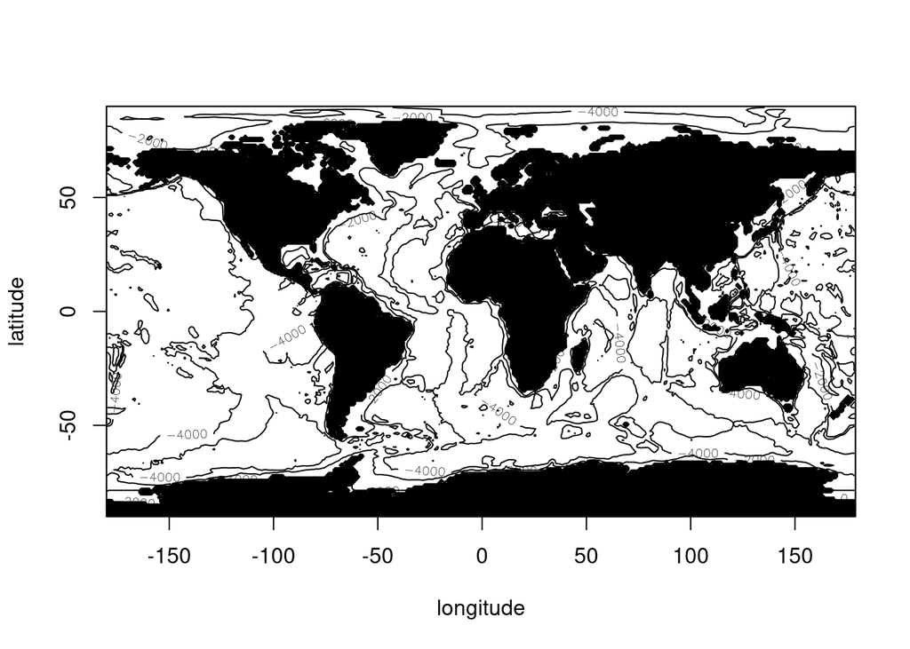